# TO 414 GP1: Hotel Chain Data Analysis

Shibi Sanjeev, Alexa Cornetta, Ben Tahmoush, Albi Popaj, Gjergj Camaj

2/20/2021

Our first Group Project asks us to analyze the hotel_bookings data and extract meaningful business insights from it. We will walk you through our findings and analysis in this report.

## **Recommendations**

After conducting an analysis of two years worth of data from 2015 to 2017, we have come up with a set of recommendations that will improve the business. To review how we came to these recommendations, please look at the following analysis.

**Recommendation 1** Create incentives for longer stays at the resorts because, on average, resort reservations tend to be longer than city hotel reservations. These incentives could come in the form of a points rewards program, which could be cashed in during their stay or during a future booking.

**Recommendation 2** Reduce the amount of cancellations from individuals who make reservations far in advance. This could be through various incentives like the points rewards programs or better deals when making early reservations.

**Recommendation 3** When conducting marketing and developing relationships with different market segments, we recommend focusing on online travel agents, direct reservations, offline travel agents or tour operators, and groups. Prioritize as follows,

1.) Online Travel Agents

2.) Offline Travel Agents or Tour Operators

3.) Direct Reservations

4.) Group Reservations

**Recommendation 4** Create programs to incentivize larger groups or large families to make reservations. This could also be through a points rewards program.

## **Import and Data Cleaning**

First, we are importing the hotel_bookings dataset, so that we may begin to explore and gain helpful insights from it. Now we will identify variables that would be most helpful to us as factors, and convert them into such

```r
library(tidyverse)
library(knitr)
hotel_data = read.csv("hotel_bookings.csv")

#Converting to factors
hotel_data$arrival_date_year = as.factor(hotel_data$arrival_date_year)
hotel_data$arrival_date_month = as.factor(hotel_data$arrival_date_month)
hotel_data$arrival_date_week_number = as.factor(hotel_data$arrival_date_week_number)
hotel_data$arrival_date_day_of_month = as.factor(hotel_data$arrival_date_day_of_month)
hotel_data$is_repeated_guest = as.factor(hotel_data$is_repeated_guest)
hotel_data$company = as.factor(hotel_data$company)
hotel_data$hotel = as.factor(hotel_data$hotel)
hotel_data$country = as.factor(hotel_data$country)
hotel_data$market_segment = as.factor(hotel_data$market_segment)
hotel_data$distribution_channel = as.factor(hotel_data$distribution_channel)
hotel_data$reserved_room_type = as.factor(hotel_data$reserved_room_type)
hotel_data$assigned_room_type = as.factor(hotel_data$assigned_room_type)
hotel_data$agent = as.factor(hotel_data$agent)
hotel_data$reservation_status_date = as.factor(hotel_data$reservation_status_date)
hotel_data$reservation_status = as.factor(hotel_data$reservation_status)
hotel_data$customer_type = as.factor(hotel_data$customer_type)
hotel_data$deposit_type = as.factor(hotel_data$deposit_type)
```

#### **Adding New Variables**

```r
#How many reservations has a person made with this hotel chain
hotel_data$total_reservations = hotel_data$previous_bookings_not_canceled + hotel_data$previous_cancellations
#Adds new variable that changes the month of arrival from a word to a numeric. Instead of January, it will give 1
hotel_data$month_num = match(hotel_data$arrival_date_month, month.name)
```

## **Cancellations**

An important initial note. We don’t have the data for every month in every year. In 2016, we have data for all twelve months. In 2017, we have data from January until August. In 2015, we only have data from July to December. The only months with three years of data are July and August. All other months only have two years worth of data from either 2015 and 2016 or 2016 and 2017.

#### **Number of cancellations broken down by year and month**

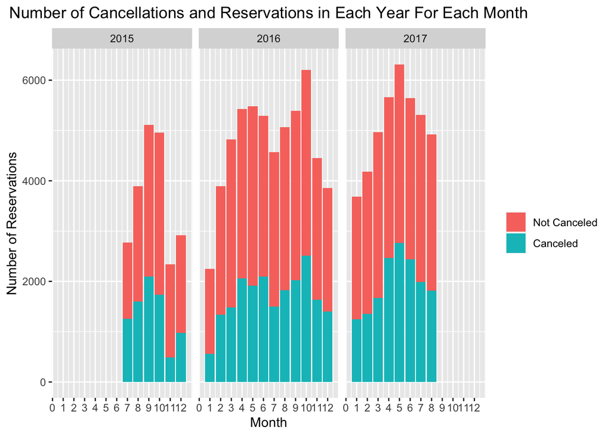

```r
#Number of cancellations broken down by year then month
res_breakdown_by_year_month = group_by(hotel_data, arrival_date_year, month_num, is_canceled) %>%
  summarize(num_reservations = n())

#Graphical representation of # of cancellations and reservations by year and month
ggplot(res_breakdown_by_year_month, aes(x = month_num, y = num_reservations)) +
  geom_bar(aes(fill = as.factor(is_canceled)),stat = "identity") +
  facet_wrap(~arrival_date_year) +
  scale_x_continuous(name="Month", breaks = seq(0,12, 1)) +
  scale_y_continuous(name="Number of Reservations") +
  scale_fill_discrete(name = "", labels = c("Not Canceled", "Canceled")) +
  ggtitle("Number of Cancellations and Reservations in Each Year For Each Month") +
  theme(plot.title = element_text(hjust = 0.5))
```

#### **Percent of Reservations Canceled in Each Year and Month**

Using a percentage is more helpful for us to analyze, as conclusions could be skewed if we just look at the number of cancellations without taking into account the total reservations as well.

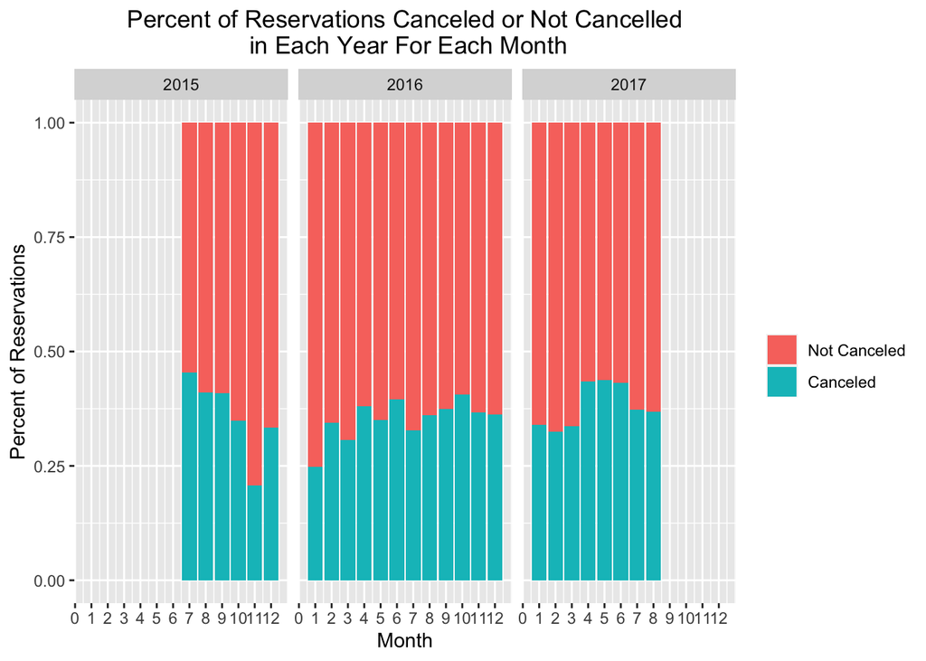

```r
#Number of reservations canceled by year, and month
t = hotel_data %>%
  group_by(arrival_date_year, month_num) %>%
  summarize(num_reservations_made = n()) %>%
   arrange(desc(arrival_date_year, month_num))

#Num reservations by year, and month
t1 = hotel_data %>%
  group_by(arrival_date_year, month_num, is_canceled) %>%
  summarize(num_reservations = n()) %>%
  arrange(arrival_date_year, month_num)

#Duplicating the dataframe t so that it can bind with dataframe t1
t2 = rbind(t, t) %>%
  arrange(arrival_date_year, month_num)

#Final Dataframe
t4 = (cbind(t1, t2) %>%
  select(arrival_date_year, month_num, is_canceled, num_reservations, num_reservations_made) %>%
  mutate(percent_reservations = num_reservations/num_reservations_made))

#Generating Bargraph
ggplot(t4, aes(x = month_num, y = percent_reservations)) +
  geom_bar(aes(fill = as.factor(is_canceled)),stat = "identity") +
  facet_wrap(~arrival_date_year) +
  scale_x_continuous(name="Month", breaks = seq(0,12, 1)) +
  scale_y_continuous(name="Percent of Reservations") +
  scale_fill_discrete(name = "", labels = c("Not Canceled", "Canceled")) +
  ggtitle("Percent of Reservations Canceled or Not Cancelled\n in Each Year For Each Month") +
  theme(plot.title = element_text(hjust = 0.5))
```

#### **Lead Time and Cancellations**

We can see that the reservations made further in advance are more likely to be canceled than those that are booked closer to the arrival date. This is likely because there is a higher probability of commitment when there is a shorter period of time and you are less likely to have unforeseen changes to plans.

**Charge higher deposit fees when reservations are made far in advance. Or incentivize rewards for not canceling reservation when it is made far in advance.**

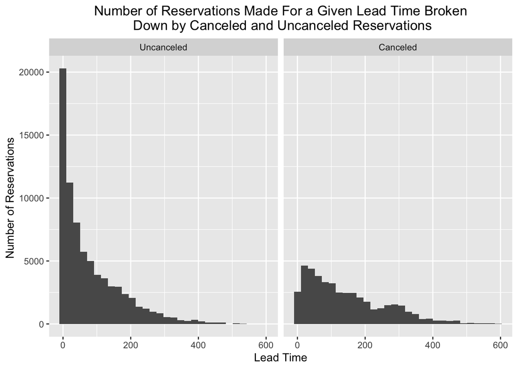

```r
supp.labs <- c("Uncanceled", "Canceled")
names(supp.labs) <- c("0", "1")

#Histograms of lead time by whether or not there were cancellations.
filter(hotel_data, lead_time < 600) %>%
ggplot(aes(x = lead_time)) +
  geom_histogram() +
  ylab("Number of Reservations ") +
  xlab("Lead Time") +
  ggtitle("Number of Reservations Made For a Given Lead Time Broken\n Down by Canceled and Uncanceled Reservations") +
  facet_wrap(~is_canceled, labeller = labeller(is_canceled = supp.labs)) +
  theme(plot.title = element_text(hjust = 0.5))
```

#### **Deposit Fees and Cancellations**

We are seeing that 99% of non refundable reservations were canceled. While our calculation makes sense, this is hard to understand in a real world context. **Is there a mistake with the data?**

```r
group_by(hotel_data, deposit_type) %>%
  summarize(count = n(), cancellations = sum(is_canceled), percent_canceled = (sum(is_canceled)/n())*100) %>%
  kable()
```

| deposit_type | count | cancellations | percent_canceled |
| --- | --- | --- | --- |
| No Deposit | 104641 | 29694 | 28.37702 |
| Non Refund | 14587 | 14494 | 99.36245 |
| Refundable | 162 | 36 | 22.22222 |

## **City vs Resort Hotels**

We are looking now at if there is a meaningful differences between city vs resort hotels

#### **Number of Reservations at City Hotels and Resort Hotels**

City hotel reservations are canceled almost 42% of the time while resort hotels are canceled almost 28% time. City hotels should consider overbooking to accomdate for the high cancellation rate.

```r
#Calculating the total length of stay
hotel_data$total_stay = hotel_data$stays_in_week_nights + hotel_data$stays_in_weekend_nights

group_by(hotel_data, hotel) %>%
  summarize(count = n(), percent_canceled = (sum(is_canceled)/n())*100, avg_daily_rate = mean(adr, na.rm = T), avg_stay = mean(total_stay, na.rm = T)) %>%
  kable()
```

| hotel | count | percent_canceled | avg_daily_rate | avg_stay |
| --- | --- | --- | --- | --- |
| City Hotel | 79330 | 41.72696 | 105.30447 | 2.978142 |
| Resort Hotel | 40060 | 27.76336 | 94.95293 | 4.318547 |

#### **Percent of Reservations Canceled in Each Year and Month Broken Down By Hotel Type**

When breaking down the cancellations further by year and month, we can see that, on average, trips to resorts are canceled less than trips to the city hotels. This is most likely because resort trips will more often than not be for vacation, whereas city hotel trips could be for business or a multitude of other reasons. An important note is that there almost twice as many reservations at city hotels than resorts, which could contribute to the difference in cancellation rates.

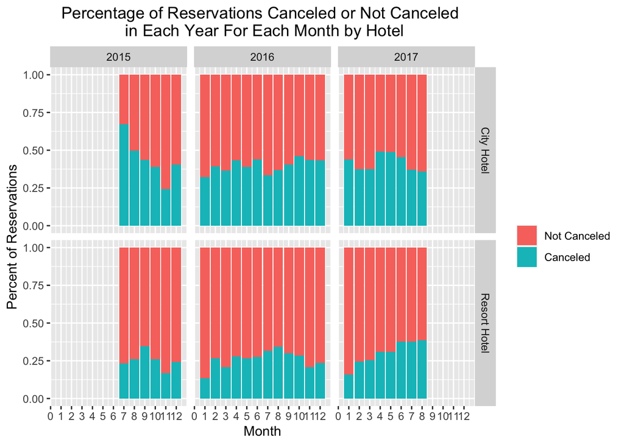

```r
#Number of reservations canceled by hotel type, year, and month
t1 = hotel_data %>%
  group_by(hotel, arrival_date_year, month_num, is_canceled) %>%
  summarize(num_reservations = n()) %>%
  arrange(hotel, arrival_date_year, month_num)

#Num reservations by hotel type, year, and month
t = hotel_data %>%
  group_by(hotel, arrival_date_year, month_num) %>%
  summarize(num_reservations_made = n()) %>%
   arrange(desc(hotel, arrival_date_year, month_num))

#Duplicating the dataframe t so that it can bind with dataframe t1
t2 = rbind(t, t) %>%
  arrange(hotel, arrival_date_year, month_num)

#Final Dataframe
t4 = (cbind(t1, t2) %>%
  select(hotel, arrival_date_year, month_num, is_canceled, num_reservations, num_reservations_made) %>%
  mutate(percent_reservations = num_reservations/num_reservations_made))

#Generating Bargraph
ggplot(t4, aes(x = month_num, y = percent_reservations)) +
  geom_bar(aes(fill = as.factor(is_canceled)),stat = "identity") +
  facet_grid(hotel ~ arrival_date_year) +
  scale_x_continuous(name="Month", breaks = seq(0,12, 1)) +
  scale_y_continuous(name="Percent of Reservations") +
  scale_fill_discrete(name = "", labels = c("Not Canceled", "Canceled")) +
  ggtitle("Percentage of Reservations Canceled or Not Canceled \n in Each Year For Each Month by Hotel") +
  theme(plot.title = element_text(hjust = 0.5))
```

#### **Length of Stay**

While the median stay is about the same length, we can see that when breaking down the length of reservations by hotel type, we can see that for both city and resort hotels, reservations typically tend to be around 2 to 5 days. But the average reservation for city hotels and resorts is 2.98 days and 4.31 days respectively.

**Have incentives for longer stays at resorts because people tend to make longer reservations there.**

```r
#Table of summary data of total stay broken down by city and resort hotels
City_Hotel_Data = summary(filter(hotel_data, hotel == "City Hotel")$total_stay)

Resort_Hotel_Data = summary(filter(hotel_data, hotel == "Resort Hotel")$total_stay)

(total_stay_data = kable(as.data.frame(cbind(City_Hotel_Data, Resort_Hotel_Data))))
```

|  | City_Hotel_Data | Resort_Hotel_Data |
| --- | --- | --- |
| Min. | 0.000000 | 0.000000 |
| 1st Qu. | 2.000000 | 2.000000 |
| Median | 3.000000 | 3.000000 |
| Mean | 2.978142 | 4.318547 |
| 3rd Qu. | 4.000000 | 7.000000 |
| Max. | 57.000000 | 69.000000 |

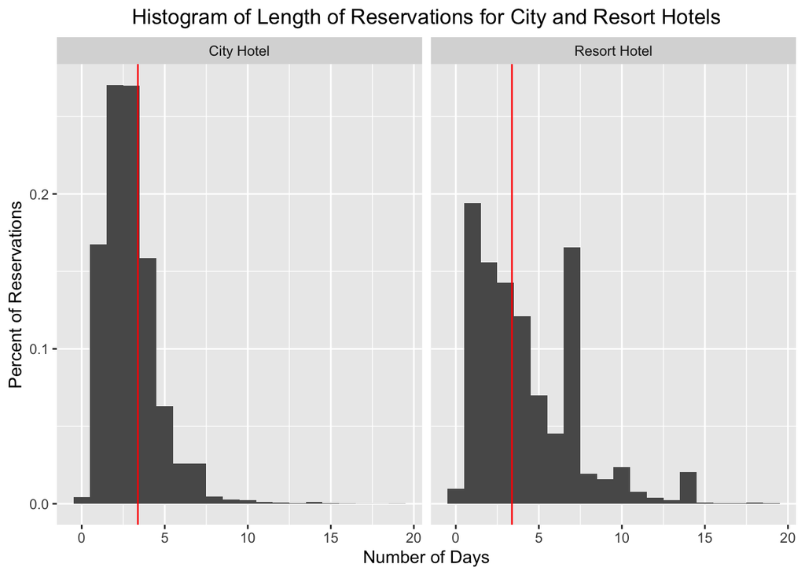

```r
#Histogram showing distribution of percentage of reservations for length of stay broken down by city and resort hotels

#Red line represents the mean of the distribution

filter(hotel_data, total_stay < 20) %>%
ggplot(aes(x = total_stay)) +
  geom_histogram(aes(y = stat(density)), binwidth = 1) +
  facet_wrap(~hotel) +
  ggtitle("Histogram of Length of Reservations for City and Resort Hotels") +
  scale_x_continuous(name="Number of Days") +
  scale_y_continuous(name="Percent of Reservations") +
  theme(plot.title = element_text(hjust = 0.5)) +
  geom_vline(aes(xintercept= mean(total_stay, na.rm = T)), size=0.5, color="red")
```

## **Market Segment**

#### **Market Segment and Average Daily Rate**

An important note is that almost 61% of reservations made by groups are canceled. Another one is that while Aviation does have a high daily rate, there have only been 237 reservations placed over this two year period.

**We would recommend focusing marketing and trying to boost traction with online travel agents, direct reservations, offline travel agents or tour operators, and groups. This is because these all have relatively high average daily rates and make up a significant portion of the number of reservations. From our estimates of total revenue, we can see that online travel agents, offline travel agents, and direct reservations account for the largest chunk of revenue for the hotel chain. When prioritizing, we would focus on online travel agents, then offline travel agents or tour operators, then direct reservations.**

```r
market_segment_info = (group_by(hotel_data, market_segment) %>%
  summarize(
    avg_daily_rate = round(mean(adr, na.rm = T), 2),
    avg_stay = mean(total_stay, na.rm = T),
    count = n(),
    num_cancellations = sum(is_canceled),
    total_revenue = round((round(mean(adr, na.rm = T), 2)*mean(total_stay, na.rm = T))*(n() - sum(is_canceled)), 2)) %>%
  mutate(percent_canceled = round((num_cancellations/count)*100, 2)) %>%
  arrange(desc(avg_daily_rate)))

kable(market_segment_info)
```

| market_segment | avg_daily_rate | avg_stay | count | num_cancellations | total_revenue | percent_canceled |
| --- | --- | --- | --- | --- | --- | --- |
| Online TA | 117.20 | 3.573986 | 56477 | 20739 | 14969616.94 | 36.72 |
| Direct | 115.45 | 3.205775 | 12606 | 1934 | 3949778.99 | 15.34 |
| Aviation | 100.14 | 3.607595 | 237 | 52 | 66833.94 | 21.94 |
| Offline TA/TO | 87.35 | 3.903877 | 24219 | 8311 | 5424686.33 | 34.32 |
| Groups | 79.48 | 2.992529 | 19811 | 12097 | 1834745.87 | 61.06 |
| Corporate | 69.36 | 2.092918 | 5295 | 992 | 624644.06 | 18.73 |
| Undefined | 15.00 | 1.500000 | 2 | 2 | 0.00 | 100.00 |
| Complementary | 2.89 | 1.647376 | 743 | 97 | 3075.55 | 13.06 |

## **Age Analysis**

#### **Average Daily Rate and Number of Adults, Children, and Babies**

An important technical note, is that we removed reservations with an average daily rate of more than 1000, because those were severe outliers. Additionally, we only looked at reservations with less than 5 adults, 10 children and 4 babies. This was because there wasn’t enough reservations above those thresholds to generate readable boxplots.

For children, adults, and babies, as the number increases, the average daily rate also increases. This could be because more rooms have to be booked, more money spent in hotel restaurants, or any other increased expense from higher headcount. There should be an incentive program or higher rewards for reservations with greater number of people. It should also be noted that we don’t have any cost data. Our hypothesis would be that average daily cost would also increase as average daily rate increases, which could have an impact on overall profit. We would need to see cost data before making a full conclusion.

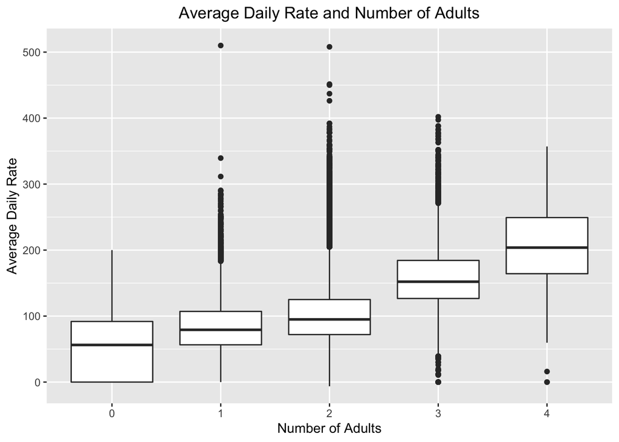

```r
#average daily rate and adults
filter(hotel_data, adr < 1000, adults < 5) %>%
ggplot(aes(x = as.factor(adults), y = adr)) +
  geom_boxplot() +
  xlab("Number of Adults") +
  ylab("Average Daily Rate") +
  ggtitle("Average Daily Rate and Number of Adults") +
  theme(plot.title = element_text(hjust = 0.5))
```

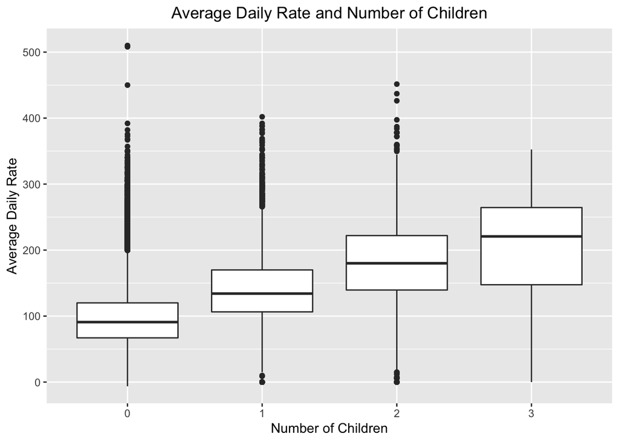

```r
#average daily rate and children
filter(hotel_data, adr < 1000, children < 10) %>%
  ggplot(aes(x = as.factor(children), y = adr)) +
  geom_boxplot() +
  xlab("Number of Children") +
  ylab("Average Daily Rate") +
  ggtitle("Average Daily Rate and Number of Children") +
  theme(plot.title = element_text(hjust = 0.5))
```

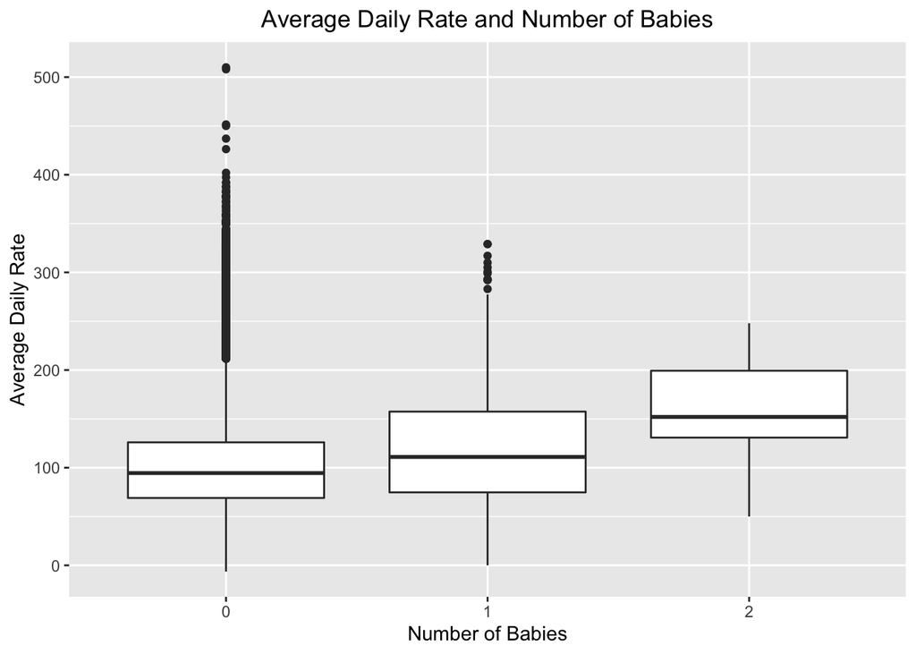

```r
#average daily rate and babies
filter(hotel_data, adr < 1000, babies < 4) %>%
  ggplot(aes(x = as.factor(babies), y = adr)) +
  geom_boxplot() +
  xlab("Number of Babies") +
  ylab("Average Daily Rate") +
  ggtitle("Average Daily Rate and Number of Babies") +
  theme(plot.title = element_text(hjust = 0.5))
```

#### **Cancellations and Number of Children**

We can see here that there doesn’t seem to be a trend between the percentage of reservations canceled and the number of children or adults within a reservation. There appears to be a higher cancellation rate for reservations without a baby than those with one, however, in all three cases, there is a significant mismatch in the number of observations.

**There could be a relationship between the cancellation percentage and adults, babies, or children, however, we don’t have the necessary data to make a conclusion at this time.**

```r
filter(hotel_data, children < 5) %>%
group_by(children) %>%
  summarize(count = n(), percent_canceled = sum(is_canceled)/n()) %>%
  arrange(desc(percent_canceled)) %>%
  kable()
```

| children | count | percent_canceled |
| --- | --- | --- |
| 2 | 3652 | 0.4219606 |
| 0 | 110796 | 0.3708979 |
| 1 | 4861 | 0.3223617 |
| 3 | 76 | 0.2236842 |

```r
filter(hotel_data, adults < 5) %>%
group_by(adults) %>%
  summarize(count = n(), percent_canceled = sum(is_canceled)/n()) %>%
  arrange(desc(percent_canceled)) %>%
  kable()
```

| adults | count | percent_canceled |
| --- | --- | --- |
| 2 | 89680 | 0.3931534 |
| 3 | 6202 | 0.3468236 |
| 1 | 23027 | 0.2898337 |
| 0 | 403 | 0.2704715 |
| 4 | 62 | 0.2580645 |

```r
filter(hotel_data, babies < 4) %>%
group_by(babies) %>%
  summarize(count = n(), percent_canceled = sum(is_canceled)/n()) %>%
  arrange(desc(percent_canceled)) %>%
  kable()
```

| babies | count | percent_canceled |
| --- | --- | --- |
| 0 | 118473 | 0.3718738 |
| 1 | 900 | 0.1833333 |
| 2 | 15 | 0.1333333 |